# fft_python

#### Raghav K. Chhetri

07-21-2021

- Discrete Fourier Transform (DFT) is a way to transform a discrete signal from time to frequency domain by summing over a sequence of sine and cosine waves. Fast Fourier Transform (FFT) is an algorithm to rapidly compute DFT
- [2D FFT speed test](https://thomasaarholt.github.io/fftspeedtest/fftspeedtest.html) shows `torch.fft` as the fastest option

Multiple ways to compute FFT in Python:

1. `numpy.fft`
2. `scipy.fftpack` -- Considered legacy. SciPy recommends using `scipy.fft`
3. `scipy.fft`
4. `pyfftw`
5. `cupy.fft` -- NVIDIA's library that evaluates FFTs on GPUs
6. `torch.FFT`
- `scipy.fft` is slightly faster than `numpy.fft`, so using that in this notebook

```python
import sys
print('Environment: {}'.format(sys.exec_prefix))
print('Executable: {}'.format(sys.executable))
print('Version: {}'.format(sys.version))
```

```
Environment: C:\Users\Raghav\anaconda3\envs\fourier
Executable: C:\Users\Raghav\anaconda3\envs\fourier\python.exe
Version: 3.9.4 (default, Apr  9 2021, 11:43:21) [MSC v.1916 64 bit (AMD64)]
```

```python
import numpy as np

import scipy.misc
from scipy import ndimage, signal
from scipy.fft import fft, ifft, fftn, ifftn, fftshift, ifftshift, fftfreq, rfft, irfft, rfftfreq

import skimage
from skimage.util import img_as_float
from skimage.data import camera, gravel, checkerboard
from skimage.filters import difference_of_gaussians, window

import matplotlib
from matplotlib import cm
import matplotlib.pyplot as plt
plt.style.use('seaborn-poster')
%matplotlib inline

print('numpy: {}'.format(np.__version__))
print('scipy: {}'.format(scipy.__version__))
print('skimage: {}'.format(skimage.__version__))
print('matplotlib: {}'.format(matplotlib.__version__))
```

```
numpy: 1.20.1
scipy: 1.6.2
skimage: 0.18.1
matplotlib: 3.3.4
```

### 1D FFT (for time-series data)

```python
srate = 2000 # Sampling rate in Hz
duration = 2 # in seconds
t = np.arange(0,duration,1./srate) # Time Vector in seconds
npnts  = len(t)

# 1D signal
freq1 = 1.0
x = 3*np.sin(2*np.pi*freq1*t)

freq2 = 4.0
x += np.cos(2*np.pi*freq2*t)

freq3 = 7.0
x += 0.5* np.cos(2*np.pi*freq3*t+np.pi/4)
```

##### Method 1 (Frequency mirroring above Nyquist):

Manually define the frequency axis in this range, `[0, Sampling Rate]`. The FFT Amplitude of the signal now has frequency peaks that are mirrored in the `[Nyquist, Sampling Rate]` too. Ignore the mirrored peaks and only consider this range, `[0 to Nyquist frequency]`. Recall that Nyquist frequency is half of the Sampling Rate.

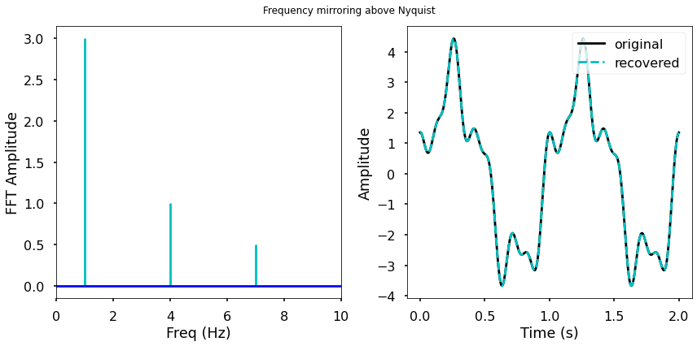

```python
# FFT of the signal
X = fft(x)
n = np.arange(npnts)
T = npnts/srate
freq = n/T

plt.figure(figsize = (12, 6))
plt.suptitle('Frequency mirroring above Nyquist')
plt.subplot(121)
plt.stem(freq, 2*np.abs(X)/npnts, 'c', markerfmt=" ", basefmt="-b")
plt.xlabel('Freq (Hz)')
plt.ylabel('FFT Amplitude')
plt.xlim(0, 10)

plt.subplot(122)
plt.plot(t, x, 'k',label='original')
plt.plot(t, ifft(X), 'c--',label='recovered')
plt.xlabel('Time (s)')
plt.ylabel('Amplitude')
plt.tight_layout()
plt.legend()
plt.show()
```

```python
print('Number of time points:', npnts, 'points')
print('Number of points in frequency range:', len(freq), 'points')
print('Frequency range:', min(freq), max(freq), 'Hz')
```

```
Number of time points: 4000 points
Number of points in frequency range: 4000 points
Frequency range: 0.0 1999.5 Hz
```

Note that the amplitude spectrum (power spectrum) is generated by plotting `2*np.abs(X)/npnts`, instead of simply `np.abs(X)`, versus frequency. This normalization is performed to get the actual amplitude values of the sine waves that we used to generate the signal (3.0, 1.0, and 0.5 at the three frequencies respectively)

##### Method 2 (Frequency mirroring about zero):

Define the frequency axis using `fftfreq` which centers the output of `fft()`. The frequency axis now extends from `[-Nyquist, Nyquist]` and the peaks are mirrored in the negative axis. Again, ignore the negative frequency and only consider this range, `[0 to Nyquist frequency]`

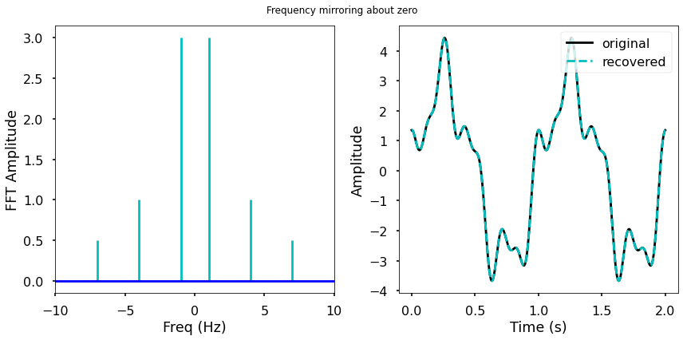

```python
# FFT of the signal
X = fft(x)
freqq = fftfreq(npnts, 1/srate)

plt.figure(figsize = (12, 6))
plt.suptitle('Frequency mirroring about zero')
plt.subplot(121)
#plt.stem(freqq, np.abs(X),'c', markerfmt=" ", basefmt="-b")
plt.stem(freqq, 2*np.abs(X)/npnts,'c', markerfmt=" ", basefmt="-b")
plt.xlabel('Freq (Hz)')
plt.ylabel('FFT Amplitude')
plt.xlim(-10, 10)

plt.subplot(122)
plt.plot(t, x, 'k',label='original')
plt.plot(t, ifft(X), 'c--',label='recovered')
plt.xlabel('Time (s)')
plt.ylabel('Amplitude')
plt.tight_layout()
plt.legend()
plt.show()
```

```python
print('Number of time points:', npnts, 'points')
print('Number of points in frequency range:', len(freqq), 'points')
print('Frequency range:', min(freqq), max(freqq), 'Hz')
```

```
Number of time points: 4000 points
Number of points in frequency range: 4000 points
Frequency range: -1000.0 999.5 Hz
```

##### Method 3 (No mirroring-- only positive frequencies):

The frequency spectrum that `fft()` outputted was reflected about the y-axis, which is caused by inputting real numbers instead of complex numbers to `fft()`. This symmetry can be taken advantage of to make Fourier transform faster by computing only the positive frequencies, which is what `rfft()` does.

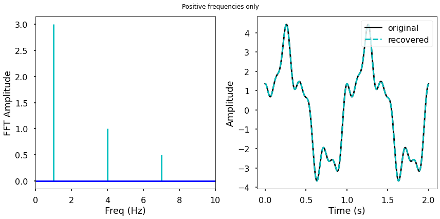

```python
# FFT of the signal
rX = rfft(x)
rfreq = rfftfreq(npnts, 1/srate)

plt.figure(figsize = (12, 6))
plt.suptitle('Positive frequencies only')
plt.subplot(121)
plt.stem(rfreq, 2*np.abs(rX)/npnts,'c', markerfmt=" ", basefmt="-b")
plt.xlabel('Freq (Hz)')
plt.ylabel('FFT Amplitude')
plt.xlim(0, 10)

plt.subplot(122)
plt.plot(t, x, 'k',label='original')
plt.plot(t, irfft(rX), 'c--',label='recovered')
plt.xlabel('Time (s)')
plt.ylabel('Amplitude')
plt.tight_layout()
plt.legend()
plt.show()
```

```python
print('Number of time points:', npnts, 'points')
print('Number of points in frequency range:', len(rfreq), 'points')
print('Frequency range:', min(rfreq), max(rfreq), 'Hz')
```

```
Number of time points: 4000 points
Number of points in frequency range: 2001 points
Frequency range: 0.0 1000.0 Hz
```

```python
%timeit fft(x)
%timeit rfft(x)
```

```
71.5 µs ± 184 ns per loop (mean ± std. dev. of 7 runs, 10000 loops each)
56.9 µs ± 261 ns per loop (mean ± std. dev. of 7 runs, 10000 loops each)
```

Also, note that `fft` takes longer if `npnts` is not a multiple of 2 and even longer if it is a prime

##### Spurious frequency peaks in Amplitude Spectrum

Let's change the frequencies of the signal to non-integer values. When we do so, we see that the FFT amplitude shows up with spurious frequency peaks

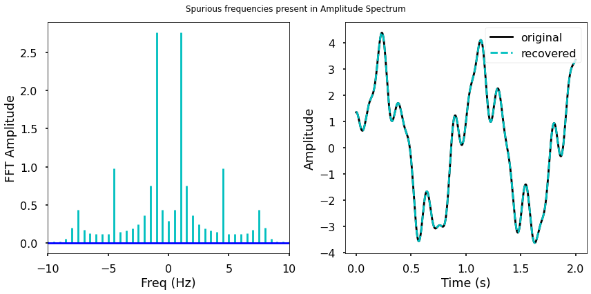

```python
srate = 2000 # Sampling rate in Hz
duration = 2 # in seconds
t = np.arange(0,duration,1./srate) # Time Vector in seconds
npnts = len(t)

# Signal
freq1 = 1.1
x = 3*np.sin(2*np.pi*freq1*t)

freq2 = 4.5
x += np.cos(2*np.pi*freq2*t)

freq3 = 7.7
x += 0.5* np.cos(2*np.pi*freq3*t+np.pi/4)

# FFT of the signal
X = fft(x)
freqq = fftfreq(npnts, 1/srate)

plt.figure(figsize = (12, 6))
plt.suptitle('Spurious frequencies present in Amplitude Spectrum')
plt.subplot(121)
plt.stem(freqq, 2*np.abs(X)/npnts,'c', markerfmt=" ", basefmt="-b")
plt.xlabel('Freq (Hz)')
plt.ylabel('FFT Amplitude')
plt.xlim(-10, 10)

plt.subplot(122)
plt.plot(t, x, 'k',label='original')
plt.plot(t, ifft(X), 'c--',label='recovered')
plt.xlabel('Time (s)')
plt.ylabel('Amplitude')
plt.tight_layout()
plt.legend()
plt.show()
```

One way to mitigate these additional frequency components is to use a longer signal, as shown below:

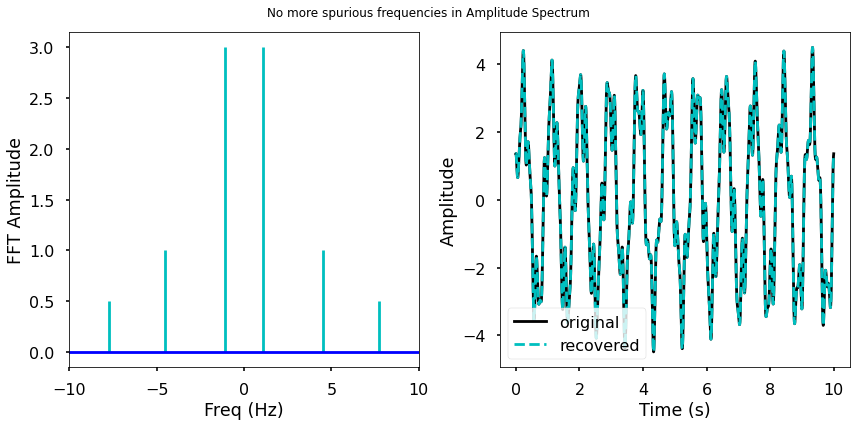

```python
srate = 2000 # Sampling rate in Hz
duration = 10 # in seconds
t = np.arange(0,duration,1./srate) # Time Vector in seconds
npnts = len(t)

# Signal
freq1 = 1.1
x = 3*np.sin(2*np.pi*freq1*t)

freq2 = 4.5
x += np.cos(2*np.pi*freq2*t)

freq3 = 7.7
x += 0.5* np.cos(2*np.pi*freq3*t+np.pi/4)

# FFT of the signal
X = fft(x)
freqq = fftfreq(npnts, 1/srate)

plt.figure(figsize = (12, 6))
plt.suptitle('No more spurious frequencies in Amplitude Spectrum')
plt.subplot(121)
plt.stem(freqq, 2*np.abs(X)/npnts,'c', markerfmt=" ", basefmt="-b")
plt.xlabel('Freq (Hz)')
plt.ylabel('FFT Amplitude')
plt.xlim(-10, 10)

plt.subplot(122)
plt.plot(t, x, 'k',label='original')
plt.plot(t, ifft(X), 'c--',label='recovered')
plt.xlabel('Time (s)')
plt.ylabel('Amplitude')
plt.tight_layout()
plt.legend()
plt.show()
```

- Note: Some of this was adapted from [Python Numerical Methods (2020), Chapter 24: Fourier Transform](https://pythonnumericalmethods.berkeley.edu/notebooks/chapter24.04-FFT-in-Python.html)

### 2D FFT (working with images)

#### 1. Blurring an image with 2D FFT

Adapted from the following [numpy example](https://scipython.com/book/chapter-6-numpy/examples/blurring-an-image-with-a-two-dimensional-fft/)

```python
tmp = scipy.misc.face(gray=True) #Racoon face from SciPy
image = tmp[128:640, 256:768]
image.shape
```

```
(512, 512)
```

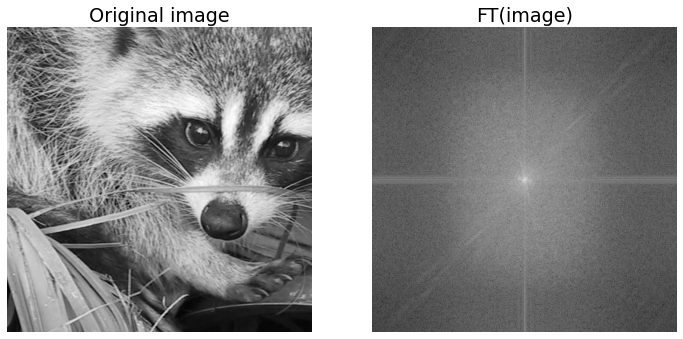

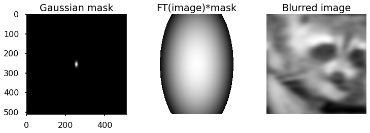

```python
plt.figure(figsize = (12, 6))
plt.subplot(121)
plt.title('Original image')
plt.axis('off')
plt.imshow(image,cmap='gray');

# Take the 2-dimensional FFT and center the frequencies
ftimage = fftn(image)
ftimage = fftshift(ftimage)

plt.subplot(122)
#plt.imshow(np.abs(ftimage))
plt.imshow(np.log(np.abs(ftimage)), cmap='gray')
plt.title('FT(image)')
plt.axis('off')
plt.show()

# Build and apply a Gaussian filter
sigmax, sigmay = 7, 13
size = image.shape[0]
cy, cx = size/2, size/2
x = np.linspace(0, size, size)
y = np.linspace(0, size, size)
X, Y = np.meshgrid(x, y)
gmask = np.exp(-(((X-cx)/sigmax)**2 + ((Y-cy)/sigmay)**2))
#Note: mask is in Fourier space; same size as FT(image)

plt.figure(figsize = (12, 6))
plt.subplot(131)
plt.imshow(gmask, cmap='gray')
plt.title('Gaussian mask')

ftimagep = ftimage * gmask
plt.subplot(132)
plt.imshow(np.log(np.abs(ftimagep)),cmap='gray')
plt.title('FT(image)*mask')
plt.axis('off')

# Finally, take the inverse transform and show the blurred image
imagep = np.fft.ifftn(ftimagep)

plt.subplot(133)
plt.imshow(np.abs(imagep), cmap='gray')
plt.title('Blurred image')
plt.axis('off')
plt.show()
```

#### 2. Gaussian blur implemented using FFT convolution: `fftconvolve`

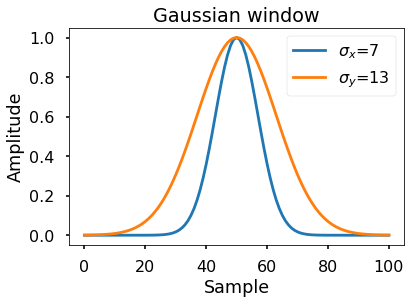

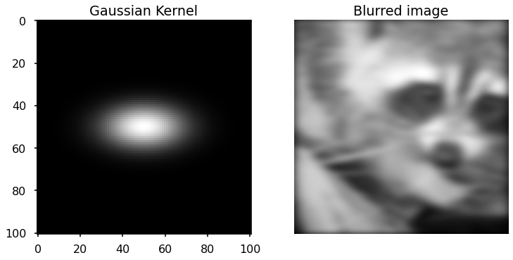

```python
#From https://docs.scipy.org/doc/scipy/reference/generated/scipy.signal.fftconvolve.html
window_x = signal.windows.gaussian(101, std=7)
window_y = signal.windows.gaussian(101, std=13)

plt.plot(window_x, label= "$\sigma_x$=7")
plt.plot(window_y, label= "$\sigma_y$=13")
plt.legend(loc="upper right")
plt.title("Gaussian window")
plt.ylabel("Amplitude")
plt.xlabel("Sample")

kernel = np.outer(window_x, window_y)
#Note: Kernel is in the same coordinate as the image; Its size is smaller compared to image

plt.figure(figsize = (12, 6))
plt.subplot(121)
plt.imshow(kernel, cmap='gray')
plt.title('Gaussian Kernel')

blurred = signal.fftconvolve(image, kernel, mode='same')

plt.subplot(122)
plt.imshow(blurred, cmap='gray')
plt.title('Blurred image')
plt.axis('off')
plt.show()
```

Notice the dark borders around the image, due to zero-padding beyond its boundaries. `scipy.ndimage.gaussian_filter` gets rid of this artifact.

#### 3. Gaussian blur using `SciPy.ndimage`

Adapted from the following [SciPy lecture](http://scipy-lectures.org/advanced/image_processing/auto_examples/plot_face_denoise.html)

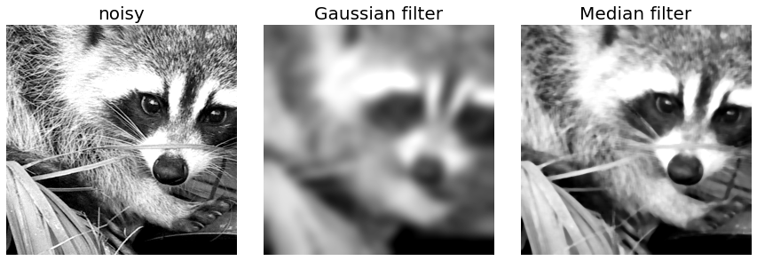

```python
# Image Denoising: Gaussian filter, Median filter
noisy = image + 0.4*image.std()*np.random.random(image.shape)

gauss_denoised = ndimage.gaussian_filter(noisy, sigma = 11)
med_denoised = ndimage.median_filter(noisy, size = 9)

plt.figure(figsize=(12,4))

plt.subplot(131)
plt.imshow(noisy, cmap=plt.cm.gray, vmin=40, vmax=220)
plt.axis('off')
plt.title('noisy', fontsize=20)
plt.subplot(132)
plt.imshow(gauss_denoised, cmap=plt.cm.gray, vmin=40, vmax=220)
plt.axis('off')
plt.title('Gaussian filter', fontsize=20)
plt.subplot(133)
plt.imshow(med_denoised, cmap=plt.cm.gray, vmin=40, vmax=220)
plt.axis('off')
plt.title('Median filter', fontsize=20)

plt.subplots_adjust(wspace=0.02, hspace=0.02, top=0.9, bottom=0, left=0, right=1)
plt.show()
```

Note that a Gaussian filter smooths out the noise and the edges. Median filter averages the noise and preserves the edges better

#### Band-pass filtering by Difference of Gaussians

Adapted from the following `SciKit-Image` [documentation](https://scikit-image.org/docs/stable/auto_examples/filters/plot_dog.html)

Band-pass filters attenuate signal frequencies outside of a range (band) of interest. In image analysis, they can be used to denoise images while at the same time reducing low-frequency artifacts such a uneven illumination. Band-pass filters can be used to find image features such as blobs and edges.

One method for applying band-pass filters to images is to subtract an image blurred with a Gaussian kernel from a less-blurred image. This example shows two applications of the Difference of Gaussians approach for band-pass filtering.

More on DoG [here](https://towardsdatascience.com/computer-vision-feature-extraction-101-on-medical-images-part-3-difference-of-gaussian-and-b3cbe5c37415)

##### 1. Denoise image and reduce shadows

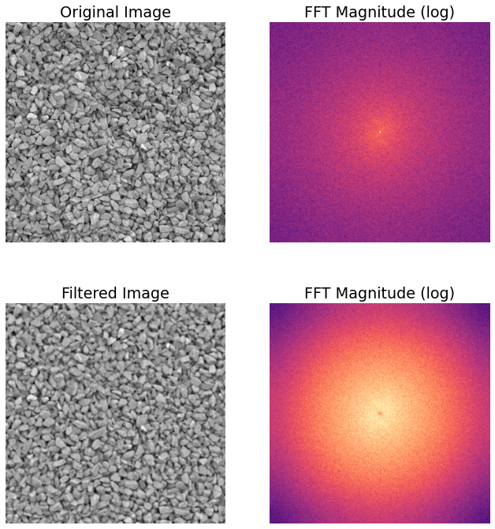

```python
image = gravel()
wimage = image * window('hann', image.shape)  # window image to improve FFT
filtered_image = difference_of_gaussians(image, 1, 12)
filtered_wimage = filtered_image * window('hann', image.shape)
im_f_mag = fftshift(np.abs(fftn(wimage)))
fim_f_mag = fftshift(np.abs(fftn(filtered_wimage)))

fig, ax = plt.subplots(nrows=2, ncols=2, figsize=(11, 12))
ax[0, 0].imshow(image, cmap='gray')
ax[0, 0].set_title('Original Image')
ax[0, 0].axis('off')
ax[0, 1].imshow(np.log(im_f_mag), cmap='magma')
ax[0, 1].set_title('FFT Magnitude (log)')
ax[0, 1].axis('off')
ax[1, 0].imshow(filtered_image, cmap='gray')
ax[1, 0].set_title('Filtered Image')
ax[1, 0].axis('off')
ax[1, 1].imshow(np.log(fim_f_mag), cmap='magma')
ax[1, 1].set_title('FFT Magnitude (log)')
ax[1, 1].axis('off')
plt.show()
```

##### 2. Enhance edges in an image

[figure not shown]

```python
image = camera()
#image = noisy
wimage = image * window('hann', image.shape)  # window image to improve FFT
filtered_image = difference_of_gaussians(image, 1.5)
filtered_wimage = filtered_image * window('hann', image.shape)
im_f_mag = fftshift(np.abs(fftn(wimage)))
fim_f_mag = fftshift(np.abs(fftn(filtered_wimage)))

fig, ax = plt.subplots(nrows=2, ncols=2, figsize=(11, 12))
ax[0, 0].imshow(image, cmap='gray')
ax[0, 0].set_title('Original Image')
ax[0, 0].axis('off')
ax[0, 1].imshow(np.log(im_f_mag), cmap='magma')
ax[0, 1].set_title('Original FFT Magnitude (log)')
ax[0, 1].axis('off')
ax[1, 0].imshow(filtered_image, cmap='gray')
ax[1, 0].set_title('Filtered Image')
ax[1, 0].axis('off')
ax[1, 1].imshow(np.log(fim_f_mag), cmap='magma')
ax[1, 1].set_title('Filtered FFT Magnitude (log)')
ax[1, 1].axis('off')
plt.show()
```

### Diffraction-limited imaging simulation

- Adopted from Computational Fourier Optics A MATLAB Tutorial, Chapter 7, page 123

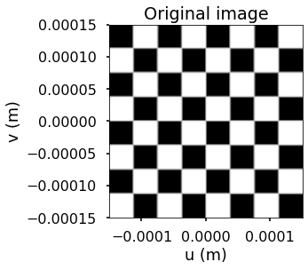

```python
#Coherent Image Simulation
img = checkerboard()
img = np.flipud(img)
M, N = img.shape
L = 0.3e-3 # image length in m
du = L/M # sample interval (m)

u = np.arange(-L/2, L/2, du)
v = np.arange(-L/2, L/2, du)

fimage = img_as_float(img)
imgfield = np.sqrt(fimage) # ideal image field

plt.figure()
plt.title('Original image')
plt.imshow(imgfield, extent=[-L/2, L/2, -L/2, L/2], cmap='gray')
plt.xlabel('u (m)')
plt.ylabel('v (m)')
plt.show()
```

```python
lamda = 0.5e-6 # wavelength in m
wxp = 6.25e-3 # exit pupil radius in m
zxp = 125e-3 # exit pupil distance in m
f0 = wxp/(lamda*zxp) # cutoff frequency

#freq coords
fu = np.arange(-1/(2*du), 1/(2*du), 1/L)
fv = np.arange(-1/(2*du), 1/(2*du), 1/L)

Fu,Fv = np.meshgrid(fu,fv)
H = np.sqrt(Fu**2 + Fv**2)/f0 < 1
```

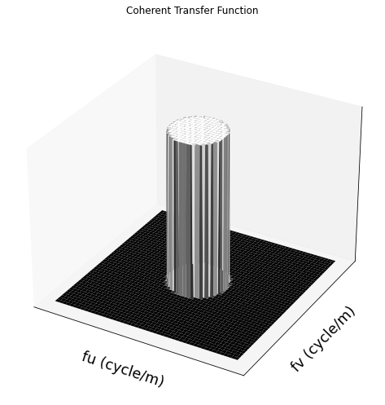

```python
fig = plt.figure(figsize=(9,7))
fig.suptitle('Coherent Transfer Function')
ax = fig.add_subplot(projection='3d')

# Plot the surface
ax.plot_surface(Fu, Fv, H, cmap=cm.gray)
fig.tight_layout()
ax.get_xaxis().set_ticks([])
ax.set_xlabel('fu (cycle/m)')
ax.get_yaxis().set_ticks([])
ax.set_ylabel('fv (cycle/m)')
ax.get_zaxis().set_ticks([])
plt.show()
```

```python
H = fftshift(H)
Gg = fftn(fftshift(imgfield))
Gi = np.multiply(Gg, H)
ui = ifftshift(ifftn(Gi))
Ii = (np.abs(ui))**2
```

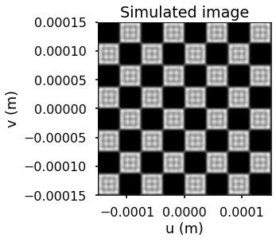

```python
#Simulated diffraction-limited coherent image
plt.figure()
plt.title('Simulated image')
plt.imshow(Ii, extent=[-L/2, L/2, -L/2, L/2], cmap='gray')
plt.xlabel('u (m)')
plt.ylabel('v (m)')
plt.show()
```